# ⚠️ SDK Migration Notice

```
================================================================================
PHASE 1: Querying full period for all companies (2024-01-01 to 2024-06-30)
         Mode: iterative
================================================================================
    [ITERATIVE MODE] Querying 40 companies in 1 batches of 500 across 1 date sub-range(s) (1 work items, max_workers=1)
    Each batch iterates until no new companies are found (max 10 iterations)
```

```
      Batch 1/1, Iter 1: Found 38 new companies, 2 remaining
```

```
      Batch 1/1, Iter 2: Found 0 new companies, 2 remaining
      Batch 1 complete: 38 found, 2 very_low, 2 iterations
    Completed 2 queries across 1 date sub-range(s). Found 38 companies with chunks > 0, 2 very_low

Phase 1 complete: 2 comention queries
Found 38 companies with chunks > 0


Pre-computing volume time series for 6 groups exceeding 1000 chunks (outer pool_workers=6, shared rate limiter)...
```

```
    Group 1 (1 companies): 181 data points, 2908 total chunks
    Group 5 (1 companies): 168 data points, 1074 total chunks
    Group 4 (1 companies): 177 data points, 1425 total chunks
    Group 0 (1 companies): 182 data points, 3774 total chunks
    Group 3 (1 companies): 176 data points, 2236 total chunks
```

```
    Group 2 (1 companies): 177 data points, 2247 total chunks
  Pre-computed volume for 6/6 groups

Created 9 entity groups (min_entities_per_group=1)
  Group 0: 1 companies, 3774 total chunks, bucket=high
  Group 1: 1 companies, 2908 total chunks, bucket=high
  Group 2: 1 companies, 2247 total chunks, bucket=high
  Group 3: 1 companies, 2236 total chunks, bucket=high
  Group 4: 1 companies, 1425 total chunks, bucket=high
  Group 5: 1 companies, 1074 total chunks, bucket=high
  Group 6: 2 companies, 844 total chunks, bucket=medium
  Group 7: 4 companies, 900 total chunks, bucket=medium
  Group 8: 26 companies, 950 total chunks, bucket=low
  Zero chunks: 2 companies

================================================================================
PHASE 2: Planning SMART configuration (per-group time splits)
================================================================================
    Group 0: using pre-computed volume data
  Group 0: 4 period(s) (split_4_volume), 4 basket(s)
    Group 1: using pre-computed volume data
  Group 1: 4 period(s) (split_3_volume), 4 basket(s)
    Group 2: using pre-computed volume data
  Group 2: 3 period(s) (split_3_volume), 3 basket(s)
    Group 3: using pre-computed volume data
  Group 3: 4 period(s) (split_3_volume), 4 basket(s)
    Group 4: using pre-computed volume data
  Group 4: 3 period(s) (split_2_volume), 3 basket(s)
    Group 5: using pre-computed volume data
  Group 5: 3 period(s) (split_2_volume), 3 basket(s)
  Group 6: 1 period (full_range), 1 basket
  Group 7: 1 period (full_range), 1 basket
  Group 8: 1 period (full_range), 1 basket
2026-08-28 11:33:13,660 - INFO - Planning complete: 16,358 expected chunks in 25 baskets
```

```
2026-08-28 11:33:13,661 - INFO - Executing search with 5.0% of chunks
```

```
2026-08-28 11:33:13,661 - INFO - Total maximum expected chunks: 817
```

```
2026-08-28 11:33:13,661 - INFO - Searching 25 baskets
```

```
2026-08-28 11:33:14,912 - INFO - Basket basket_14_high_20240629_20240630: Retrieved 1 documents with 1 chunks
```

```
2026-08-28 11:33:15,246 - INFO - Basket basket_24_very_low_20240101_20240630: Retrieved 0 documents with 0 chunks
```

```
2026-08-28 11:33:15,449 - INFO - Basket basket_10_high_20240608_20240630: Retrieved 32 documents with 37 chunks
```

```
2026-08-28 11:33:15,507 - INFO - Basket basket_21_medium_20240101_20240630: Retrieved 42 documents with 42 chunks
```

```
2026-08-28 11:33:15,595 - INFO - Basket basket_0_high_20240101_20240229: Retrieved 41 documents with 47 chunks
```

```
2026-08-28 11:33:15,641 - INFO - Basket basket_5_high_20240229_20240506: Retrieved 44 documents with 47 chunks
```

```
2026-08-28 11:33:15,687 - INFO - Basket basket_11_high_20240101_20240309: Retrieved 33 documents with 37 chunks
```

```
2026-08-28 11:33:15,709 - INFO - Basket basket_7_high_20240628_20240630: Retrieved 1 documents with 1 chunks
```

```
2026-08-28 11:33:15,711 - INFO - Basket basket_20_high_20240630_20240630: Retrieved 1 documents with 1 chunks
```

```
2026-08-28 11:33:15,926 - INFO - Basket basket_17_high_20240701_20240701: Retrieved 12 documents with 16 chunks
```

```
2026-08-28 11:33:15,928 - INFO - Progress: 10/25 baskets completed
```

```
2026-08-28 11:33:16,008 - INFO - Basket basket_18_high_20240101_20240412: Retrieved 23 documents with 26 chunks
```

```
2026-08-28 11:33:16,020 - INFO - Basket basket_12_high_20240310_20240505: Retrieved 33 documents with 37 chunks
```

```
2026-08-28 11:33:16,036 - INFO - Basket basket_19_high_20240413_20240629: Retrieved 23 documents with 26 chunks
```

```
2026-08-28 11:33:16,058 - INFO - Basket basket_13_high_20240506_20240628: Retrieved 32 documents with 37 chunks
```

```
2026-08-28 11:33:16,138 - INFO - Basket basket_16_high_20240416_20240630: Retrieved 33 documents with 35 chunks
```

```
2026-08-28 11:33:16,176 - INFO - Basket basket_8_high_20240101_20240321: Retrieved 33 documents with 37 chunks
```

```
2026-08-28 11:33:16,179 - INFO - Basket basket_1_high_20240301_20240418: Retrieved 42 documents with 47 chunks
```

```
2026-08-28 11:33:16,185 - INFO - Basket basket_9_high_20240322_20240607: Retrieved 33 documents with 37 chunks
```

```
2026-08-28 11:33:16,225 - INFO - Basket basket_6_high_20240507_20240627: Retrieved 43 documents with 47 chunks
```

```
2026-08-28 11:33:16,237 - INFO - Basket basket_2_high_20240419_20240602: Retrieved 43 documents with 47 chunks
```

```
2026-08-28 11:33:16,240 - INFO - Basket basket_4_high_20240101_20240228: Retrieved 41 documents with 48 chunks
```

```
2026-08-28 11:33:16,242 - INFO - Progress: 20/25 baskets completed
```

```
2026-08-28 11:33:16,243 - INFO - Basket basket_22_medium_20240101_20240630: Retrieved 43 documents with 45 chunks
```

```
2026-08-28 11:33:16,269 - INFO - Basket basket_3_high_20240603_20240630: Retrieved 41 documents with 45 chunks
```

```
2026-08-28 11:33:16,298 - INFO - Basket basket_15_high_20240101_20240415: Retrieved 31 documents with 35 chunks
```

```
2026-08-28 11:33:16,301 - INFO - Basket basket_23_low_20240101_20240630: Retrieved 44 documents with 47 chunks
```

```
2026-08-28 11:33:16,303 - INFO - First pass complete: 745 documents with 825 chunks
```

```
2026-08-28 11:33:16,303 - INFO - Search complete: 745 documents with 825 chunks retrieved in 2.64s
```

```
2026-08-28 11:33:16,304 - WARNING - Failed baskets: 1
```

```
2026-08-28 11:33:16,310 - INFO - Deduplicated: 435 unique documents from 745 total (chunks merged)
```

```
2026-08-28 11:33:16,311 - INFO - Planning search for text: 'Businesses employing AI for income growth'
```

```
2026-08-28 11:33:16,311 - INFO - Date range: 2024-01-01 to 2024-06-30
```

```
2026-08-28 11:33:16,311 - INFO - Using 40 entity IDs from inline list
```

```
2026-08-28 11:33:16,311 - INFO - Loaded 40 companies from universe
```

```
2026-08-28 11:33:16,312 - INFO - Using SmartBatchingPlanner with adaptive time-window splitting
```

```
2026-08-28 11:33:16,312 - INFO - Using 40 entity IDs from inline list
```

```
================================================================================
PHASE 1: Querying full period for all companies (2024-01-01 to 2024-06-30)
         Mode: iterative
================================================================================
    [ITERATIVE MODE] Querying 40 companies in 1 batches of 500 across 1 date sub-range(s) (1 work items, max_workers=1)
    Each batch iterates until no new companies are found (max 10 iterations)
```

```
      Batch 1/1, Iter 1: Found 37 new companies, 3 remaining
```

```
      Batch 1/1, Iter 2: Found 1 new companies, 2 remaining
```

```
      Batch 1/1, Iter 3: Found 0 new companies, 2 remaining
      Batch 1 complete: 38 found, 2 very_low, 3 iterations
    Completed 3 queries across 1 date sub-range(s). Found 38 companies with chunks > 0, 2 very_low

Phase 1 complete: 3 comention queries
Found 38 companies with chunks > 0


Pre-computing volume time series for 7 groups exceeding 1000 chunks (outer pool_workers=7, shared rate limiter)...
```

```
    Group 2 (1 companies): 181 data points, 3791 total chunks
    Group 5 (1 companies): 180 data points, 2611 total chunks
    Group 3 (1 companies): 179 data points, 3036 total chunks
    Group 1 (1 companies): 182 data points, 5715 total chunks
    Group 0 (1 companies): 182 data points, 7048 total chunks
    Group 6 (1 companies): 152 data points, 1007 total chunks
    Group 4 (1 companies): 180 data points, 2961 total chunks
  Pre-computed volume for 7/7 groups

Created 12 entity groups (min_entities_per_group=1)
  Group 0: 1 companies, 7048 total chunks, bucket=high
  Group 1: 1 companies, 5715 total chunks, bucket=high
  Group 2: 1 companies, 3791 total chunks, bucket=high
  Group 3: 1 companies, 3036 total chunks, bucket=high
  Group 4: 1 companies, 2961 total chunks, bucket=high
  Group 5: 1 companies, 2611 total chunks, bucket=high
  Group 6: 1 companies, 1007 total chunks, bucket=high
  Group 7: 1 companies, 582 total chunks, bucket=high
  Group 8: 2 companies, 907 total chunks, bucket=medium
  Group 9: 3 companies, 866 total chunks, bucket=medium
  Group 10: 5 companies, 909 total chunks, bucket=medium
  Group 11: 20 companies, 737 total chunks, bucket=low
  Zero chunks: 2 companies

================================================================================
PHASE 2: Planning SMART configuration (per-group time splits)
================================================================================
    Group 0: using pre-computed volume data
  Group 0: 7 period(s) (split_8_volume), 7 basket(s)
    Group 1: using pre-computed volume data
  Group 1: 6 period(s) (split_6_volume), 6 basket(s)
    Group 2: using pre-computed volume data
  Group 2: 5 period(s) (split_4_volume), 5 basket(s)
    Group 3: using pre-computed volume data
  Group 3: 5 period(s) (split_4_volume), 5 basket(s)
    Group 4: using pre-computed volume data
  Group 4: 4 period(s) (split_3_volume), 4 basket(s)
    Group 5: using pre-computed volume data
  Group 5: 4 period(s) (split_3_volume), 4 basket(s)
    Group 6: using pre-computed volume data
  Group 6: 3 period(s) (split_2_volume), 3 basket(s)
  Group 7: 1 period (full_range), 1 basket
  Group 8: 1 period (full_range), 1 basket
  Group 9: 1 period (full_range), 1 basket
  Group 10: 1 period (full_range), 1 basket
  Group 11: 1 period (full_range), 1 basket
2026-08-28 11:33:19,966 - INFO - Planning complete: 30,170 expected chunks in 40 baskets
```

```
2026-08-28 11:33:19,966 - INFO - Executing search with 5.0% of chunks
```

```
2026-08-28 11:33:19,967 - INFO - Total maximum expected chunks: 1,508
```

```
2026-08-28 11:33:19,967 - INFO - Searching 40 baskets
```

```
2026-08-28 11:33:21,898 - INFO - Basket basket_19_high_20240210_20240411: Retrieved 34 documents with 36 chunks
```

```
2026-08-28 11:33:21,903 - INFO - Basket basket_13_high_20240101_20240302: Retrieved 45 documents with 47 chunks
```

```
2026-08-28 11:33:21,951 - INFO - Basket basket_10_high_20240410_20240508: Retrieved 44 documents with 56 chunks
```

```
2026-08-28 11:33:21,960 - INFO - Basket basket_23_high_20240101_20240229: Retrieved 40 documents with 49 chunks
```

```
2026-08-28 11:33:22,030 - INFO - Basket basket_14_high_20240303_20240412: Retrieved 44 documents with 47 chunks
```

```
2026-08-28 11:33:22,155 - INFO - Basket basket_0_high_20240101_20240131: Retrieved 53 documents with 61 chunks
```

```
2026-08-28 11:33:22,227 - INFO - Basket basket_20_high_20240412_20240510: Retrieved 33 documents with 39 chunks
```

```
2026-08-28 11:33:22,251 - INFO - Basket basket_22_high_20240701_20240701: Retrieved 16 documents with 19 chunks
```

```
2026-08-28 11:33:22,270 - INFO - Basket basket_17_high_20240629_20240630: Retrieved 1 documents with 1 chunks
```

```
2026-08-28 11:33:22,308 - INFO - Basket basket_26_high_20240627_20240630: Retrieved 2 documents with 2 chunks
```

```
2026-08-28 11:33:22,309 - INFO - Progress: 10/40 baskets completed
```

```
2026-08-28 11:33:22,327 - INFO - Basket basket_33_high_20240625_20240630: Retrieved 1 documents with 1 chunks
```

```
2026-08-28 11:33:22,345 - INFO - Basket basket_16_high_20240531_20240628: Retrieved 38 documents with 45 chunks
```

```
2026-08-28 11:33:22,466 - INFO - Basket basket_30_high_20240701_20240701: Retrieved 11 documents with 15 chunks
```

```
2026-08-28 11:33:22,517 - INFO - Basket basket_32_high_20240410_20240624: Retrieved 18 documents with 21 chunks
```

```
2026-08-28 11:33:22,609 - INFO - Basket basket_34_high_20240101_20240630: Retrieved 27 documents with 29 chunks
```

```
2026-08-28 11:33:22,642 - INFO - Basket basket_31_high_20240101_20240409: Retrieved 22 documents with 28 chunks
```

```
2026-08-28 11:33:22,694 - INFO - Basket basket_25_high_20240502_20240626: Retrieved 37 documents with 47 chunks
```

```
2026-08-28 11:33:22,744 - INFO - Basket basket_24_high_20240301_20240501: Retrieved 44 documents with 48 chunks
```

```
2026-08-28 11:33:22,750 - INFO - Basket basket_11_high_20240509_20240607: Retrieved 38 documents with 45 chunks
```

```
2026-08-28 11:33:22,752 - INFO - Basket basket_15_high_20240413_20240530: Retrieved 41 documents with 47 chunks
```

```
2026-08-28 11:33:22,753 - INFO - Progress: 20/40 baskets completed
```

```
2026-08-28 11:33:22,761 - INFO - Basket basket_28_high_20240229_20240512: Retrieved 39 documents with 42 chunks
```

```
2026-08-28 11:33:22,803 - INFO - Basket basket_27_high_20240101_20240228: Retrieved 41 documents with 44 chunks
```

```
2026-08-28 11:33:22,815 - INFO - Basket basket_35_medium_20240101_20240630: Retrieved 43 documents with 45 chunks
```

```
2026-08-28 11:33:22,833 - INFO - Basket basket_29_high_20240513_20240630: Retrieved 36 documents with 43 chunks
```

```
2026-08-28 11:33:22,835 - INFO - Basket basket_18_high_20240101_20240209: Retrieved 33 documents with 38 chunks
```

```
2026-08-28 11:33:22,846 - INFO - Basket basket_36_medium_20240101_20240630: Retrieved 43 documents with 43 chunks
```

```
2026-08-28 11:33:22,848 - INFO - Basket basket_1_high_20240201_20240229: Retrieved 48 documents with 56 chunks
```

```
2026-08-28 11:33:22,854 - INFO - Basket basket_21_high_20240511_20240630: Retrieved 31 documents with 37 chunks
```

```
2026-08-28 11:33:23,138 - INFO - Basket basket_12_high_20240608_20240630: Retrieved 33 documents with 34 chunks
```

```
2026-08-28 11:33:23,408 - INFO - Basket basket_2_high_20240301_20240329: Retrieved 40 documents with 48 chunks
```

```
2026-08-28 11:33:23,409 - INFO - Progress: 30/40 baskets completed
```

```
2026-08-28 11:33:26,246 - INFO - Basket basket_39_very_low_20240101_20240630: Retrieved 0 documents with 0 chunks
```

```
2026-08-28 11:33:26,364 - INFO - Basket basket_6_high_20240625_20240630: Retrieved 9 documents with 10 chunks
```

```
2026-08-28 11:33:26,469 - INFO - Basket basket_38_low_20240101_20240630: Retrieved 34 documents with 36 chunks
```

```
2026-08-28 11:33:26,477 - INFO - Basket basket_37_medium_20240101_20240630: Retrieved 41 documents with 45 chunks
```

```
2026-08-28 11:33:26,485 - INFO - Basket basket_8_high_20240202_20240305: Retrieved 38 documents with 45 chunks
```

```
2026-08-28 11:33:26,522 - INFO - Basket basket_5_high_20240527_20240624: Retrieved 49 documents with 52 chunks
```

```
2026-08-28 11:33:26,569 - INFO - Basket basket_9_high_20240306_20240409: Retrieved 46 documents with 54 chunks
```

```
2026-08-28 11:33:26,663 - INFO - Basket basket_7_high_20240101_20240201: Retrieved 42 documents with 49 chunks
```

```
2026-08-28 11:33:26,885 - INFO - Basket basket_4_high_20240428_20240526: Retrieved 55 documents with 69 chunks
```

```
2026-08-28 11:33:26,918 - INFO - Basket basket_3_high_20240330_20240427: Retrieved 45 documents with 54 chunks
```

```
2026-08-28 11:33:26,919 - INFO - Progress: 40/40 baskets completed
```

```
2026-08-28 11:33:26,922 - INFO - First pass complete: 1335 documents with 1527 chunks
```

```
2026-08-28 11:33:26,922 - INFO - Search complete: 1335 documents with 1527 chunks retrieved in 6.95s
```

```
2026-08-28 11:33:26,922 - WARNING - Failed baskets: 1
```

```
2026-08-28 11:33:26,927 - INFO - Deduplicated: 918 unique documents from 1335 total (chunks merged)
```

```
2026-08-28 11:33:26,929 - INFO - Planning search for text: 'Organizations implementing AI for financial gains'
```

```
2026-08-28 11:33:26,930 - INFO - Date range: 2024-01-01 to 2024-06-30
```

```
2026-08-28 11:33:26,930 - INFO - Using 40 entity IDs from inline list
```

```
2026-08-28 11:33:26,930 - INFO - Loaded 40 companies from universe
```

```
2026-08-28 11:33:26,930 - INFO - Using SmartBatchingPlanner with adaptive time-window splitting
```

```
2026-08-28 11:33:26,931 - INFO - Using 40 entity IDs from inline list
```

```
================================================================================
PHASE 1: Querying full period for all companies (2024-01-01 to 2024-06-30)
         Mode: iterative
================================================================================
    [ITERATIVE MODE] Querying 40 companies in 1 batches of 500 across 1 date sub-range(s) (1 work items, max_workers=1)
    Each batch iterates until no new companies are found (max 10 iterations)
```

```
      Batch 1/1, Iter 1: Found 37 new companies, 3 remaining
```

```
      Batch 1/1, Iter 2: Found 0 new companies, 3 remaining
      Batch 1 complete: 37 found, 3 very_low, 2 iterations
    Completed 2 queries across 1 date sub-range(s). Found 37 companies with chunks > 0, 3 very_low

Phase 1 complete: 2 comention queries
Found 37 companies with chunks > 0


Pre-computing volume time series for 3 groups exceeding 1000 chunks (outer pool_workers=3, shared rate limiter)...
```

```
    Group 2 (1 companies): 168 data points, 1080 total chunks
    Group 0 (1 companies): 178 data points, 1901 total chunks
    Group 1 (1 companies): 178 data points, 1459 total chunks
  Pre-computed volume for 3/3 groups

Created 8 entity groups (min_entities_per_group=1)
  Group 0: 1 companies, 1901 total chunks, bucket=high
  Group 1: 1 companies, 1459 total chunks, bucket=high
  Group 2: 1 companies, 1080 total chunks, bucket=high
  Group 3: 1 companies, 897 total chunks, bucket=high
  Group 4: 1 companies, 888 total chunks, bucket=high
  Group 5: 2 companies, 838 total chunks, bucket=high
  Group 6: 12 companies, 994 total chunks, bucket=low
  Group 7: 18 companies, 203 total chunks, bucket=low
  Zero chunks: 3 companies

================================================================================
PHASE 2: Planning SMART configuration (per-group time splits)
================================================================================
    Group 0: using pre-computed volume data
  Group 0: 3 period(s) (split_2_volume), 3 basket(s)
    Group 1: using pre-computed volume data
  Group 1: 3 period(s) (split_2_volume), 3 basket(s)
    Group 2: using pre-computed volume data
  Group 2: 3 period(s) (split_2_volume), 3 basket(s)
  Group 3: 1 period (full_range), 1 basket
  Group 4: 1 period (full_range), 1 basket
  Group 5: 1 period (full_range), 1 basket
  Group 6: 1 period (full_range), 1 basket
  Group 7: 1 period (full_range), 1 basket
2026-08-28 11:33:29,628 - INFO - Planning complete: 8,260 expected chunks in 15 baskets
```

```
2026-08-28 11:33:29,629 - INFO - Executing search with 5.0% of chunks
```

```
2026-08-28 11:33:29,629 - INFO - Total maximum expected chunks: 413
```

```
2026-08-28 11:33:29,630 - INFO - Searching 15 baskets
```

```
2026-08-28 11:33:31,044 - INFO - Basket basket_14_very_low_20240101_20240630: Retrieved 0 documents with 0 chunks
```

```
2026-08-28 11:33:31,102 - INFO - Basket basket_4_high_20240424_20240628: Retrieved 31 documents with 35 chunks
```

```
2026-08-28 11:33:31,137 - INFO - Basket basket_3_high_20240101_20240423: Retrieved 30 documents with 36 chunks
```

```
2026-08-28 11:33:31,211 - INFO - Basket basket_0_high_20240101_20240406: Retrieved 36 documents with 47 chunks
```

```
2026-08-28 11:33:31,219 - INFO - Basket basket_8_high_20240628_20240630: Retrieved 1 documents with 1 chunks
```

```
2026-08-28 11:33:31,258 - INFO - Basket basket_5_high_20240629_20240630: Retrieved 1 documents with 1 chunks
```

```
2026-08-28 11:33:31,267 - INFO - Basket basket_10_high_20240101_20240630: Retrieved 40 documents with 44 chunks
```

```
2026-08-28 11:33:31,287 - INFO - Basket basket_9_high_20240101_20240630: Retrieved 39 documents with 44 chunks
```

```
2026-08-28 11:33:31,335 - INFO - Basket basket_6_high_20240101_20240410: Retrieved 23 documents with 27 chunks
```

```
2026-08-28 11:33:31,363 - INFO - Basket basket_2_high_20240701_20240701: Retrieved 10 documents with 12 chunks
```

```
2026-08-28 11:33:31,363 - INFO - Progress: 10/15 baskets completed
```

```
2026-08-28 11:33:31,429 - INFO - Basket basket_12_low_20240101_20240630: Retrieved 47 documents with 49 chunks
```

```
2026-08-28 11:33:31,455 - INFO - Basket basket_13_low_20240101_20240630: Retrieved 9 documents with 10 chunks
```

```
2026-08-28 11:33:31,629 - INFO - Basket basket_7_high_20240411_20240627: Retrieved 24 documents with 26 chunks
```

```
2026-08-28 11:33:31,726 - INFO - Basket basket_11_high_20240101_20240630: Retrieved 37 documents with 41 chunks
```

```
2026-08-28 11:33:31,886 - INFO - Basket basket_1_high_20240407_20240630: Retrieved 38 documents with 47 chunks
```

```
2026-08-28 11:33:31,887 - INFO - First pass complete: 366 documents with 420 chunks
```

```
2026-08-28 11:33:31,887 - INFO - Search complete: 366 documents with 420 chunks retrieved in 2.26s
```

```
2026-08-28 11:33:31,887 - WARNING - Failed baskets: 1
```

```
2026-08-28 11:33:31,894 - INFO - Deduplicated: 247 unique documents from 366 total (chunks merged)
```

```
2026-08-28 11:33:31,895 - INFO - Planning search for text: 'Companies utilizing AI for profit maximization'
```

```
2026-08-28 11:33:31,896 - INFO - Date range: 2024-01-01 to 2024-06-30
```

```
2026-08-28 11:33:31,896 - INFO - Using 40 entity IDs from inline list
```

```
2026-08-28 11:33:31,896 - INFO - Loaded 40 companies from universe
```

```
2026-08-28 11:33:31,897 - INFO - Using SmartBatchingPlanner with adaptive time-window splitting
```

```
2026-08-28 11:33:31,897 - INFO - Using 40 entity IDs from inline list
```

```
================================================================================
PHASE 1: Querying full period for all companies (2024-01-01 to 2024-06-30)
         Mode: iterative
================================================================================
    [ITERATIVE MODE] Querying 40 companies in 1 batches of 500 across 1 date sub-range(s) (1 work items, max_workers=1)
    Each batch iterates until no new companies are found (max 10 iterations)
```

```
      Batch 1/1, Iter 1: Found 37 new companies, 3 remaining
```

```
      Batch 1/1, Iter 2: Found 1 new companies, 2 remaining
```

```
      Batch 1/1, Iter 3: Found 0 new companies, 2 remaining
      Batch 1 complete: 38 found, 2 very_low, 3 iterations
    Completed 3 queries across 1 date sub-range(s). Found 38 companies with chunks > 0, 2 very_low

Phase 1 complete: 3 comention queries
Found 38 companies with chunks > 0


Pre-computing volume time series for 6 groups exceeding 1000 chunks (outer pool_workers=6, shared rate limiter)...
```

```
    Group 0 (1 companies): 182 data points, 3509 total chunks
    Group 1 (1 companies): 178 data points, 2815 total chunks
    Group 4 (1 companies): 177 data points, 1389 total chunks
    Group 2 (1 companies): 179 data points, 2663 total chunks
    Group 3 (1 companies): 178 data points, 1761 total chunks
```

```
    Group 5 (1 companies): 173 data points, 1382 total chunks
  Pre-computed volume for 6/6 groups

Created 10 entity groups (min_entities_per_group=1)
  Group 0: 1 companies, 3509 total chunks, bucket=high
  Group 1: 1 companies, 2815 total chunks, bucket=high
  Group 2: 1 companies, 2663 total chunks, bucket=high
  Group 3: 1 companies, 1761 total chunks, bucket=high
  Group 4: 1 companies, 1389 total chunks, bucket=high
  Group 5: 1 companies, 1382 total chunks, bucket=high
  Group 6: 2 companies, 840 total chunks, bucket=medium
  Group 7: 3 companies, 884 total chunks, bucket=medium
  Group 8: 6 companies, 976 total chunks, bucket=medium
  Group 9: 21 companies, 697 total chunks, bucket=low
  Zero chunks: 2 companies

================================================================================
PHASE 2: Planning SMART configuration (per-group time splits)
================================================================================
    Group 0: using pre-computed volume data
  Group 0: 4 period(s) (split_4_volume), 4 basket(s)
    Group 1: using pre-computed volume data
  Group 1: 4 period(s) (split_3_volume), 4 basket(s)
    Group 2: using pre-computed volume data
  Group 2: 4 period(s) (split_3_volume), 4 basket(s)
    Group 3: using pre-computed volume data
  Group 3: 3 period(s) (split_2_volume), 3 basket(s)
    Group 4: using pre-computed volume data
  Group 4: 3 period(s) (split_2_volume), 3 basket(s)
    Group 5: using pre-computed volume data
  Group 5: 3 period(s) (split_2_volume), 3 basket(s)
  Group 6: 1 period (full_range), 1 basket
  Group 7: 1 period (full_range), 1 basket
  Group 8: 1 period (full_range), 1 basket
  Group 9: 1 period (full_range), 1 basket
2026-08-28 11:33:35,510 - INFO - Planning complete: 16,916 expected chunks in 26 baskets
```

```
2026-08-28 11:33:35,511 - INFO - Executing search with 5.0% of chunks
```

```
2026-08-28 11:33:35,511 - INFO - Total maximum expected chunks: 845
```

```
2026-08-28 11:33:35,511 - INFO - Searching 26 baskets
```

```
2026-08-28 11:33:37,132 - INFO - Basket basket_12_high_20240101_20240411: Retrieved 42 documents with 45 chunks
```

```
2026-08-28 11:33:37,286 - INFO - Basket basket_25_very_low_20240101_20240630: Retrieved 0 documents with 0 chunks
```

```
2026-08-28 11:33:37,336 - INFO - Basket basket_11_high_20240629_20240630: Retrieved 1 documents with 1 chunks
```

```
2026-08-28 11:33:37,389 - INFO - Basket basket_18_high_20240101_20240416: Retrieved 32 documents with 34 chunks
```

```
2026-08-28 11:33:37,467 - INFO - Basket basket_5_high_20240307_20240521: Retrieved 41 documents with 46 chunks
```

```
2026-08-28 11:33:37,516 - INFO - Basket basket_15_high_20240101_20240409: Retrieved 32 documents with 34 chunks
```

```
2026-08-28 11:33:37,527 - INFO - Basket basket_1_high_20240227_20240422: Retrieved 39 documents with 43 chunks
```

```
2026-08-28 11:33:37,637 - INFO - Basket basket_14_high_20240629_20240630: Retrieved 1 documents with 1 chunks
```

```
2026-08-28 11:33:37,694 - INFO - Basket basket_3_high_20240604_20240630: Retrieved 39 documents with 45 chunks
```

```
2026-08-28 11:33:37,747 - INFO - Basket basket_7_high_20240629_20240630: Retrieved 1 documents with 1 chunks
```

```
2026-08-28 11:33:37,748 - INFO - Progress: 10/26 baskets completed
```

```
2026-08-28 11:33:37,767 - INFO - Basket basket_17_high_20240630_20240630: Retrieved 0 documents with 0 chunks
```

```
2026-08-28 11:33:37,907 - INFO - Basket basket_22_medium_20240101_20240630: Retrieved 43 documents with 44 chunks
```

```
2026-08-28 11:33:37,937 - INFO - Basket basket_10_high_20240507_20240628: Retrieved 39 documents with 43 chunks
```

```
2026-08-28 11:33:38,048 - INFO - Basket basket_20_high_20240701_20240701: Retrieved 14 documents with 14 chunks
```

```
2026-08-28 11:33:38,080 - INFO - Basket basket_19_high_20240417_20240630: Retrieved 31 documents with 34 chunks
```

```
2026-08-28 11:33:38,113 - INFO - Basket basket_6_high_20240522_20240628: Retrieved 38 documents with 46 chunks
```

```
2026-08-28 11:33:38,148 - INFO - Basket basket_16_high_20240410_20240629: Retrieved 32 documents with 34 chunks
```

```
2026-08-28 11:33:38,152 - INFO - Basket basket_8_high_20240101_20240228: Retrieved 41 documents with 45 chunks
```

```
2026-08-28 11:33:38,159 - INFO - Basket basket_2_high_20240423_20240603: Retrieved 37 documents with 42 chunks
```

```
2026-08-28 11:33:38,174 - INFO - Basket basket_21_medium_20240101_20240630: Retrieved 41 documents with 42 chunks
```

```
2026-08-28 11:33:38,174 - INFO - Progress: 20/26 baskets completed
```

```
2026-08-28 11:33:38,206 - INFO - Basket basket_0_high_20240101_20240226: Retrieved 40 documents with 44 chunks
```

```
2026-08-28 11:33:38,209 - INFO - Basket basket_24_low_20240101_20240630: Retrieved 32 documents with 34 chunks
```

```
2026-08-28 11:33:38,300 - INFO - Basket basket_13_high_20240412_20240628: Retrieved 39 documents with 42 chunks
```

```
2026-08-28 11:33:38,318 - INFO - Basket basket_23_medium_20240101_20240630: Retrieved 46 documents with 48 chunks
```

```
2026-08-28 11:33:38,325 - INFO - Basket basket_4_high_20240101_20240306: Retrieved 47 documents with 47 chunks
```

```
2026-08-28 11:33:38,882 - INFO - Basket basket_9_high_20240229_20240506: Retrieved 37 documents with 43 chunks
```

```
2026-08-28 11:33:38,885 - INFO - First pass complete: 785 documents with 852 chunks
```

```
2026-08-28 11:33:38,886 - INFO - Search complete: 785 documents with 852 chunks retrieved in 3.37s
```

```
2026-08-28 11:33:38,886 - WARNING - Failed baskets: 2
```

```
2026-08-28 11:33:38,889 - INFO - Deduplicated: 499 unique documents from 785 total (chunks merged)
```

```
2026-08-28 11:33:38,890 - INFO - Planning search for text: 'Organizations leveraging artificial intelligence for profit'
```

```
2026-08-28 11:33:38,890 - INFO - Date range: 2024-01-01 to 2024-06-30
```

```
2026-08-28 11:33:38,891 - INFO - Using 40 entity IDs from inline list
```

```
2026-08-28 11:33:38,891 - INFO - Loaded 40 companies from universe
```

```
2026-08-28 11:33:38,891 - INFO - Using SmartBatchingPlanner with adaptive time-window splitting
```

```
2026-08-28 11:33:38,891 - INFO - Using 40 entity IDs from inline list
```

```
================================================================================
PHASE 1: Querying full period for all companies (2024-01-01 to 2024-06-30)
         Mode: iterative
================================================================================
    [ITERATIVE MODE] Querying 40 companies in 1 batches of 500 across 1 date sub-range(s) (1 work items, max_workers=1)
    Each batch iterates until no new companies are found (max 10 iterations)
```

```
      Batch 1/1, Iter 1: Found 35 new companies, 5 remaining
```

```
      Batch 1/1, Iter 2: Found 3 new companies, 2 remaining
```

```
      Batch 1/1, Iter 3: Found 0 new companies, 2 remaining
      Batch 1 complete: 38 found, 2 very_low, 3 iterations
    Completed 3 queries across 1 date sub-range(s). Found 38 companies with chunks > 0, 2 very_low

Phase 1 complete: 3 comention queries
Found 38 companies with chunks > 0


Pre-computing volume time series for 6 groups exceeding 1000 chunks (outer pool_workers=6, shared rate limiter)...
```

```
    Group 1 (1 companies): 179 data points, 3138 total chunks
    Group 4 (1 companies): 165 data points, 1261 total chunks
    Group 5 (1 companies): 160 data points, 1022 total chunks
    Group 3 (1 companies): 170 data points, 1359 total chunks
    Group 2 (1 companies): 181 data points, 2844 total chunks
    Group 0 (1 companies): 182 data points, 3944 total chunks
  Pre-computed volume for 6/6 groups

Created 10 entity groups (min_entities_per_group=1)
  Group 0: 1 companies, 3944 total chunks, bucket=high
  Group 1: 1 companies, 3138 total chunks, bucket=high
  Group 2: 1 companies, 2844 total chunks, bucket=high
  Group 3: 1 companies, 1360 total chunks, bucket=high
  Group 4: 1 companies, 1261 total chunks, bucket=high
  Group 5: 1 companies, 1022 total chunks, bucket=high
  Group 6: 2 companies, 795 total chunks, bucket=medium
  Group 7: 4 companies, 913 total chunks, bucket=medium
  Group 8: 18 companies, 995 total chunks, bucket=low
  Group 9: 8 companies, 37 total chunks, bucket=low
  Zero chunks: 2 companies

================================================================================
PHASE 2: Planning SMART configuration (per-group time splits)
================================================================================
    Group 0: using pre-computed volume data
  Group 0: 5 period(s) (split_4_volume), 5 basket(s)
    Group 1: using pre-computed volume data
  Group 1: 5 period(s) (split_4_volume), 5 basket(s)
    Group 2: using pre-computed volume data
  Group 2: 4 period(s) (split_3_volume), 4 basket(s)
    Group 3: using pre-computed volume data
  Group 3: 3 period(s) (split_2_volume), 3 basket(s)
    Group 4: using pre-computed volume data
  Group 4: 3 period(s) (split_2_volume), 3 basket(s)
    Group 5: using pre-computed volume data
  Group 5: 3 period(s) (split_2_volume), 3 basket(s)
  Group 6: 1 period (full_range), 1 basket
  Group 7: 1 period (full_range), 1 basket
  Group 8: 1 period (full_range), 1 basket
  Group 9: 1 period (full_range), 1 basket
2026-08-28 11:33:42,497 - INFO - Planning complete: 16,308 expected chunks in 28 baskets
```

```
2026-08-28 11:33:42,498 - INFO - Executing search with 5.0% of chunks
```

```
2026-08-28 11:33:42,498 - INFO - Total maximum expected chunks: 815
```

```
2026-08-28 11:33:42,498 - INFO - Searching 28 baskets
```

```
2026-08-28 11:33:43,649 - INFO - Basket basket_13_high_20240627_20240630: Retrieved 2 documents with 2 chunks
```

```
2026-08-28 11:33:43,887 - INFO - Basket basket_4_high_20240628_20240630: Retrieved 1 documents with 1 chunks
```

```
2026-08-28 11:33:43,981 - INFO - Basket basket_20_high_20240101_20240412: Retrieved 22 documents with 25 chunks
```

```
2026-08-28 11:33:43,990 - INFO - Basket basket_17_high_20240101_20240418: Retrieved 29 documents with 32 chunks
```

```
2026-08-28 11:33:44,015 - INFO - Basket basket_15_high_20240404_20240629: Retrieved 31 documents with 33 chunks
```

```
2026-08-28 11:33:44,023 - INFO - Basket basket_14_high_20240101_20240403: Retrieved 28 documents with 34 chunks
```

```
2026-08-28 11:33:44,025 - INFO - Basket basket_10_high_20240101_20240318: Retrieved 44 documents with 50 chunks
```

```
2026-08-28 11:33:44,063 - INFO - Basket basket_16_high_20240630_20240630: Retrieved 1 documents with 1 chunks
```

```
2026-08-28 11:33:44,149 - INFO - Basket basket_11_high_20240319_20240523: Retrieved 43 documents with 44 chunks
```

```
2026-08-28 11:33:44,252 - INFO - Basket basket_27_very_low_20240101_20240630: Retrieved 0 documents with 0 chunks
```

```
2026-08-28 11:33:44,253 - INFO - Progress: 10/28 baskets completed
```

```
2026-08-28 11:33:44,387 - INFO - Basket basket_2_high_20240405_20240515: Retrieved 42 documents with 48 chunks
```

```
2026-08-28 11:33:44,389 - INFO - Basket basket_9_high_20240626_20240630: Retrieved 4 documents with 4 chunks
```

```
2026-08-28 11:33:44,402 - INFO - Basket basket_19_high_20240701_20240701: Retrieved 6 documents with 8 chunks
```

```
2026-08-28 11:33:44,443 - INFO - Basket basket_26_low_20240101_20240630: Retrieved 1 documents with 1 chunks
```

```
2026-08-28 11:33:44,449 - INFO - Basket basket_22_high_20240701_20240701: Retrieved 8 documents with 8 chunks
```

```
2026-08-28 11:33:44,578 - INFO - Basket basket_7_high_20240410_20240513: Retrieved 31 documents with 32 chunks
```

```
2026-08-28 11:33:44,609 - INFO - Basket basket_21_high_20240413_20240630: Retrieved 20 documents with 25 chunks
```

```
2026-08-28 11:33:44,668 - INFO - Basket basket_25_low_20240101_20240630: Retrieved 44 documents with 49 chunks
```

```
2026-08-28 11:33:44,675 - INFO - Basket basket_0_high_20240101_20240209: Retrieved 41 documents with 50 chunks
```

```
2026-08-28 11:33:44,706 - INFO - Basket basket_23_medium_20240101_20240630: Retrieved 35 documents with 39 chunks
```

```
2026-08-28 11:33:44,706 - INFO - Progress: 20/28 baskets completed
```

```
2026-08-28 11:33:44,726 - INFO - Basket basket_18_high_20240419_20240630: Retrieved 28 documents with 31 chunks
```

```
2026-08-28 11:33:44,735 - INFO - Basket basket_8_high_20240514_20240625: Retrieved 34 documents with 39 chunks
```

```
2026-08-28 11:33:44,809 - INFO - Basket basket_12_high_20240524_20240626: Retrieved 38 documents with 44 chunks
```

```
2026-08-28 11:33:44,817 - INFO - Basket basket_6_high_20240213_20240409: Retrieved 38 documents with 41 chunks
```

```
2026-08-28 11:33:44,819 - INFO - Basket basket_3_high_20240516_20240627: Retrieved 39 documents with 48 chunks
```

```
2026-08-28 11:33:44,830 - INFO - Basket basket_5_high_20240101_20240212: Retrieved 36 documents with 39 chunks
```

```
2026-08-28 11:33:44,851 - INFO - Basket basket_24_medium_20240101_20240630: Retrieved 43 documents with 45 chunks
```

```
2026-08-28 11:33:44,864 - INFO - Basket basket_1_high_20240210_20240404: Retrieved 40 documents with 48 chunks
```

```
2026-08-28 11:33:44,865 - INFO - First pass complete: 729 documents with 821 chunks
```

```
2026-08-28 11:33:44,866 - INFO - Search complete: 729 documents with 821 chunks retrieved in 2.37s
```

```
2026-08-28 11:33:44,866 - WARNING - Failed baskets: 1
```

```
2026-08-28 11:33:44,871 - INFO - Deduplicated: 501 unique documents from 729 total (chunks merged)
```

```
2026-08-28 11:33:44,872 - INFO - Planning search for text: 'Businesses leveraging AI solutions to boost income'
```

```
2026-08-28 11:33:44,872 - INFO - Date range: 2024-01-01 to 2024-06-30
```

```
2026-08-28 11:33:44,872 - INFO - Using 40 entity IDs from inline list
```

```
2026-08-28 11:33:44,872 - INFO - Loaded 40 companies from universe
```

```
2026-08-28 11:33:44,873 - INFO - Using SmartBatchingPlanner with adaptive time-window splitting
```

```
2026-08-28 11:33:44,873 - INFO - Using 40 entity IDs from inline list
```

```
================================================================================
PHASE 1: Querying full period for all companies (2024-01-01 to 2024-06-30)
         Mode: iterative
================================================================================
    [ITERATIVE MODE] Querying 40 companies in 1 batches of 500 across 1 date sub-range(s) (1 work items, max_workers=1)
    Each batch iterates until no new companies are found (max 10 iterations)
```

```
      Batch 1/1, Iter 1: Found 37 new companies, 3 remaining
```

```
      Batch 1/1, Iter 2: Found 2 new companies, 1 remaining
```

```
      Batch 1/1, Iter 3: Found 0 new companies, 1 remaining
      Batch 1 complete: 39 found, 1 very_low, 3 iterations
    Completed 3 queries across 1 date sub-range(s). Found 39 companies with chunks > 0, 1 very_low

Phase 1 complete: 3 comention queries
Found 39 companies with chunks > 0


Pre-computing volume time series for 6 groups exceeding 1000 chunks (outer pool_workers=6, shared rate limiter)...
```

```
    Group 2 (1 companies): 181 data points, 3713 total chunks
    Group 5 (1 companies): 179 data points, 2613 total chunks
    Group 4 (1 companies): 181 data points, 2824 total chunks
    Group 1 (1 companies): 181 data points, 5373 total chunks
    Group 3 (1 companies): 179 data points, 2888 total chunks
    Group 0 (1 companies): 182 data points, 7296 total chunks
  Pre-computed volume for 6/6 groups

Created 12 entity groups (min_entities_per_group=1)
  Group 0: 1 companies, 7296 total chunks, bucket=high
  Group 1: 1 companies, 5373 total chunks, bucket=high
  Group 2: 1 companies, 3713 total chunks, bucket=high
  Group 3: 1 companies, 2888 total chunks, bucket=high
  Group 4: 1 companies, 2824 total chunks, bucket=high
  Group 5: 1 companies, 2613 total chunks, bucket=high
  Group 6: 1 companies, 771 total chunks, bucket=high
  Group 7: 1 companies, 633 total chunks, bucket=high
  Group 8: 2 companies, 763 total chunks, bucket=medium
  Group 9: 3 companies, 944 total chunks, bucket=medium
  Group 10: 6 companies, 981 total chunks, bucket=medium
  Group 11: 20 companies, 595 total chunks, bucket=low
  Zero chunks: 1 companies

================================================================================
PHASE 2: Planning SMART configuration (per-group time splits)
================================================================================
    Group 0: using pre-computed volume data
  Group 0: 7 period(s) (split_8_volume), 7 basket(s)
    Group 1: using pre-computed volume data
  Group 1: 6 period(s) (split_6_volume), 6 basket(s)
    Group 2: using pre-computed volume data
  Group 2: 5 period(s) (split_4_volume), 5 basket(s)
    Group 3: using pre-computed volume data
  Group 3: 4 period(s) (split_3_volume), 4 basket(s)
    Group 4: using pre-computed volume data
  Group 4: 4 period(s) (split_3_volume), 4 basket(s)
    Group 5: using pre-computed volume data
  Group 5: 4 period(s) (split_3_volume), 4 basket(s)
  Group 6: 1 period (full_range), 1 basket
  Group 7: 1 period (full_range), 1 basket
  Group 8: 1 period (full_range), 1 basket
  Group 9: 1 period (full_range), 1 basket
  Group 10: 1 period (full_range), 1 basket
  Group 11: 1 period (full_range), 1 basket
2026-08-28 11:33:48,463 - INFO - Planning complete: 29,394 expected chunks in 37 baskets
```

```
2026-08-28 11:33:48,464 - INFO - Executing search with 5.0% of chunks
```

```
2026-08-28 11:33:48,464 - INFO - Total maximum expected chunks: 1,469
```

```
2026-08-28 11:33:48,464 - INFO - Searching 37 baskets
```

```
2026-08-28 11:33:50,182 - INFO - Basket basket_12_high_20240607_20240630: Retrieved 28 documents with 33 chunks
```

```
2026-08-28 11:33:50,341 - INFO - Basket basket_16_high_20240602_20240630: Retrieved 39 documents with 48 chunks
```

```
2026-08-28 11:33:50,413 - INFO - Basket basket_13_high_20240101_20240228: Retrieved 42 documents with 46 chunks
```

```
2026-08-28 11:33:50,636 - INFO - Basket basket_29_high_20240626_20240630: Retrieved 2 documents with 2 chunks
```

```
2026-08-28 11:33:50,666 - INFO - Basket basket_1_high_20240201_20240229: Retrieved 51 documents with 57 chunks
```

```
2026-08-28 11:33:50,681 - INFO - Basket basket_25_high_20240629_20240630: Retrieved 1 documents with 1 chunks
```

```
2026-08-28 11:33:50,761 - INFO - Basket basket_19_high_20240301_20240521: Retrieved 44 documents with 48 chunks
```

```
2026-08-28 11:33:50,778 - INFO - Basket basket_31_high_20240101_20240630: Retrieved 30 documents with 31 chunks
```

```
2026-08-28 11:33:50,805 - INFO - Basket basket_21_high_20240629_20240630: Retrieved 1 documents with 1 chunks
```

```
2026-08-28 11:33:50,823 - INFO - Basket basket_17_high_20240701_20240701: Retrieved 27 documents with 30 chunks
```

```
2026-08-28 11:33:50,826 - INFO - Basket basket_26_high_20240101_20240227: Retrieved 40 documents with 44 chunks
```

```
2026-08-28 11:33:50,826 - INFO - Progress: 10/37 baskets completed
```

```
2026-08-28 11:33:50,832 - INFO - Basket basket_0_high_20240101_20240131: Retrieved 53 documents with 66 chunks
```

```
2026-08-28 11:33:50,888 - INFO - Basket basket_36_very_low_20240101_20240630: Retrieved 0 documents with 0 chunks
```

```
2026-08-28 11:33:50,931 - INFO - Basket basket_23_high_20240228_20240502: Retrieved 42 documents with 48 chunks
```

```
2026-08-28 11:33:51,010 - INFO - Basket basket_22_high_20240101_20240227: Retrieved 38 documents with 47 chunks
```

```
2026-08-28 11:33:51,075 - INFO - Basket basket_35_low_20240101_20240630: Retrieved 25 documents with 29 chunks
```

```
2026-08-28 11:33:51,102 - INFO - Basket basket_14_high_20240229_20240411: Retrieved 42 documents with 45 chunks
```

```
2026-08-28 11:33:51,188 - INFO - Basket basket_32_medium_20240101_20240630: Retrieved 36 documents with 38 chunks
```

```
2026-08-28 11:33:51,192 - INFO - Basket basket_2_high_20240301_20240329: Retrieved 33 documents with 46 chunks
```

```
2026-08-28 11:33:51,215 - INFO - Basket basket_27_high_20240228_20240426: Retrieved 42 documents with 43 chunks
```

```
2026-08-28 11:33:51,215 - INFO - Progress: 20/37 baskets completed
```

```
2026-08-28 11:33:51,230 - INFO - Basket basket_15_high_20240412_20240601: Retrieved 42 documents with 45 chunks
```

```
2026-08-28 11:33:51,281 - INFO - Basket basket_28_high_20240427_20240625: Retrieved 33 documents with 40 chunks
```

```
2026-08-28 11:33:51,290 - INFO - Basket basket_20_high_20240522_20240628: Retrieved 39 documents with 47 chunks
```

```
2026-08-28 11:33:51,295 - INFO - Basket basket_10_high_20240408_20240506: Retrieved 49 documents with 62 chunks
```

```
2026-08-28 11:33:51,314 - INFO - Basket basket_18_high_20240101_20240229: Retrieved 45 documents with 48 chunks
```

```
2026-08-28 11:33:51,317 - INFO - Basket basket_11_high_20240507_20240606: Retrieved 39 documents with 44 chunks
```

```
2026-08-28 11:33:51,346 - INFO - Basket basket_34_medium_20240101_20240630: Retrieved 44 documents with 49 chunks
```

```
2026-08-28 11:33:51,350 - INFO - Basket basket_33_medium_20240101_20240630: Retrieved 46 documents with 47 chunks
```

```
2026-08-28 11:33:51,378 - INFO - Basket basket_30_high_20240101_20240630: Retrieved 30 documents with 38 chunks
```

```
2026-08-28 11:33:51,700 - INFO - Basket basket_24_high_20240503_20240628: Retrieved 39 documents with 45 chunks
```

```
2026-08-28 11:33:51,701 - INFO - Progress: 30/37 baskets completed
```

```
2026-08-28 11:33:54,663 - INFO - Basket basket_6_high_20240625_20240630: Retrieved 11 documents with 13 chunks
```

```
2026-08-28 11:33:54,789 - INFO - Basket basket_9_high_20240302_20240407: Retrieved 35 documents with 43 chunks
```

```
2026-08-28 11:33:54,833 - INFO - Basket basket_5_high_20240527_20240624: Retrieved 46 documents with 56 chunks
```

```
2026-08-28 11:33:54,851 - INFO - Basket basket_8_high_20240201_20240301: Retrieved 36 documents with 39 chunks
```

```
2026-08-28 11:33:54,870 - INFO - Basket basket_3_high_20240330_20240427: Retrieved 42 documents with 55 chunks
```

```
2026-08-28 11:33:55,013 - INFO - Basket basket_4_high_20240428_20240526: Retrieved 55 documents with 69 chunks
```

```
2026-08-28 11:33:55,218 - INFO - Basket basket_7_high_20240101_20240131: Retrieved 39 documents with 45 chunks
```

```
2026-08-28 11:33:55,221 - INFO - First pass complete: 1286 documents with 1488 chunks
```

```
2026-08-28 11:33:55,222 - INFO - Search complete: 1286 documents with 1488 chunks retrieved in 6.76s
```

```
2026-08-28 11:33:55,222 - WARNING - Failed baskets: 1
```

```
2026-08-28 11:33:55,227 - INFO - Deduplicated: 884 unique documents from 1286 total (chunks merged)
```

```
2026-08-28 11:33:55,230 - INFO - Planning search for text: 'Firms using AI to drive sales'
```

```
2026-08-28 11:33:55,230 - INFO - Date range: 2024-01-01 to 2024-06-30
```

```
2026-08-28 11:33:55,230 - INFO - Using 40 entity IDs from inline list
```

```
2026-08-28 11:33:55,231 - INFO - Loaded 40 companies from universe
```

```
2026-08-28 11:33:55,231 - INFO - Using SmartBatchingPlanner with adaptive time-window splitting
```

```
2026-08-28 11:33:55,231 - INFO - Using 40 entity IDs from inline list
```

```
================================================================================
PHASE 1: Querying full period for all companies (2024-01-01 to 2024-06-30)
         Mode: iterative
================================================================================
    [ITERATIVE MODE] Querying 40 companies in 1 batches of 500 across 1 date sub-range(s) (1 work items, max_workers=1)
    Each batch iterates until no new companies are found (max 10 iterations)
```

```
      Batch 1/1, Iter 1: Found 37 new companies, 3 remaining
```

```
      Batch 1/1, Iter 2: Found 3 new companies, 0 remaining
      Batch 1 complete: 40 found, 0 very_low, 2 iterations
    Completed 2 queries across 1 date sub-range(s). Found 40 companies with chunks > 0, 0 very_low

Phase 1 complete: 2 comention queries
Found 40 companies with chunks > 0


Pre-computing volume time series for 6 groups exceeding 1000 chunks (outer pool_workers=6, shared rate limiter)...
```

```
    Group 5 (1 companies): 176 data points, 1600 total chunks
    Group 1 (1 companies): 178 data points, 3245 total chunks
    Group 4 (1 companies): 180 data points, 2226 total chunks
```

```
    Group 2 (1 companies): 181 data points, 2827 total chunks
    Group 3 (1 companies): 179 data points, 2399 total chunks
    Group 0 (1 companies): 178 data points, 3883 total chunks
  Pre-computed volume for 6/6 groups

Created 10 entity groups (min_entities_per_group=1)
  Group 0: 1 companies, 3883 total chunks, bucket=high
  Group 1: 1 companies, 3245 total chunks, bucket=high
  Group 2: 1 companies, 2827 total chunks, bucket=high
  Group 3: 1 companies, 2399 total chunks, bucket=high
  Group 4: 1 companies, 2226 total chunks, bucket=high
  Group 5: 1 companies, 1600 total chunks, bucket=high
  Group 6: 2 companies, 961 total chunks, bucket=high
  Group 7: 2 companies, 729 total chunks, bucket=medium
  Group 8: 5 companies, 989 total chunks, bucket=medium
  Group 9: 25 companies, 894 total chunks, bucket=low
  Zero chunks: 0 companies

================================================================================
PHASE 2: Planning SMART configuration (per-group time splits)
================================================================================
    Group 0: using pre-computed volume data
  Group 0: 5 period(s) (split_4_volume), 5 basket(s)
    Group 1: using pre-computed volume data
  Group 1: 5 period(s) (split_4_volume), 5 basket(s)
    Group 2: using pre-computed volume data
  Group 2: 4 period(s) (split_3_volume), 4 basket(s)
    Group 3: using pre-computed volume data
  Group 3: 4 period(s) (split_3_volume), 4 basket(s)
    Group 4: using pre-computed volume data
  Group 4: 4 period(s) (split_3_volume), 4 basket(s)
    Group 5: using pre-computed volume data
  Group 5: 3 period(s) (split_2_volume), 3 basket(s)
  Group 6: 1 period (full_range), 1 basket
  Group 7: 1 period (full_range), 1 basket
  Group 8: 1 period (full_range), 1 basket
  Group 9: 1 period (full_range), 1 basket
2026-08-28 11:33:58,498 - INFO - Planning complete: 19,753 expected chunks in 29 baskets
```

```
2026-08-28 11:33:58,498 - INFO - Executing search with 5.0% of chunks
```

```
2026-08-28 11:33:58,498 - INFO - Total maximum expected chunks: 987
```

```
2026-08-28 11:33:58,499 - INFO - Searching 29 baskets
```

```
2026-08-28 11:33:59,873 - INFO - Basket basket_0_high_20240101_20240209: Retrieved 42 documents with 49 chunks
```

```
2026-08-28 11:34:00,482 - INFO - Basket basket_17_high_20240701_20240701: Retrieved 13 documents with 20 chunks
```

```
2026-08-28 11:34:00,618 - INFO - Basket basket_18_high_20240101_20240229: Retrieved 36 documents with 37 chunks
```

```
2026-08-28 11:34:00,623 - INFO - Basket basket_12_high_20240521_20240624: Retrieved 42 documents with 45 chunks
```

```
2026-08-28 11:34:00,625 - INFO - Basket basket_25_high_20240101_20240630: Retrieved 47 documents with 48 chunks
```

```
2026-08-28 11:34:00,645 - INFO - Basket basket_10_high_20240101_20240318: Retrieved 41 documents with 47 chunks
```

```
2026-08-28 11:34:00,703 - INFO - Basket basket_15_high_20240314_20240523: Retrieved 36 documents with 39 chunks
```

```
2026-08-28 11:34:00,713 - INFO - Basket basket_24_high_20240630_20240630: Retrieved 1 documents with 1 chunks
```

```
2026-08-28 11:34:00,751 - INFO - Basket basket_3_high_20240517_20240628: Retrieved 39 documents with 47 chunks
```

```
2026-08-28 11:34:00,759 - INFO - Basket basket_6_high_20240223_20240409: Retrieved 36 documents with 40 chunks
```

```
2026-08-28 11:34:00,760 - INFO - Progress: 10/29 baskets completed
```

```
2026-08-28 11:34:00,832 - INFO - Basket basket_2_high_20240411_20240516: Retrieved 42 documents with 48 chunks
```

```
2026-08-28 11:34:00,838 - INFO - Basket basket_21_high_20240628_20240630: Retrieved 1 documents with 1 chunks
```

```
2026-08-28 11:34:00,844 - INFO - Basket basket_4_high_20240629_20240630: Retrieved 1 documents with 1 chunks
```

```
2026-08-28 11:34:00,857 - INFO - Basket basket_20_high_20240503_20240627: Retrieved 31 documents with 35 chunks
```

```
2026-08-28 11:34:00,890 - INFO - Basket basket_1_high_20240210_20240410: Retrieved 41 documents with 48 chunks
```

```
2026-08-28 11:34:00,899 - INFO - Basket basket_16_high_20240524_20240630: Retrieved 33 documents with 40 chunks
```

```
2026-08-28 11:34:00,916 - INFO - Basket basket_9_high_20240625_20240630: Retrieved 5 documents with 5 chunks
```

```
2026-08-28 11:34:00,940 - INFO - Basket basket_26_medium_20240101_20240630: Retrieved 34 documents with 36 chunks
```

```
2026-08-28 11:34:00,974 - INFO - Basket basket_19_high_20240301_20240502: Retrieved 33 documents with 36 chunks
```

```
2026-08-28 11:34:01,213 - INFO - Basket basket_7_high_20240410_20240509: Retrieved 31 documents with 34 chunks
```

```
2026-08-28 11:34:01,214 - INFO - Progress: 20/29 baskets completed
```

```
2026-08-28 11:34:01,247 - INFO - Basket basket_27_medium_20240101_20240630: Retrieved 44 documents with 49 chunks
```

```
2026-08-28 11:34:01,253 - INFO - Basket basket_8_high_20240510_20240624: Retrieved 33 documents with 40 chunks
```

```
2026-08-28 11:34:01,316 - INFO - Basket basket_5_high_20240101_20240222: Retrieved 36 documents with 42 chunks
```

```
2026-08-28 11:34:01,319 - INFO - Basket basket_22_high_20240101_20240411: Retrieved 38 documents with 40 chunks
```

```
2026-08-28 11:34:01,322 - INFO - Basket basket_14_high_20240101_20240313: Retrieved 38 documents with 40 chunks
```

```
2026-08-28 11:34:01,354 - INFO - Basket basket_28_low_20240101_20240630: Retrieved 42 documents with 44 chunks
```

```
2026-08-28 11:34:01,604 - INFO - Basket basket_13_high_20240625_20240630: Retrieved 3 documents with 5 chunks
```

```
2026-08-28 11:34:01,700 - INFO - Basket basket_23_high_20240412_20240629: Retrieved 33 documents with 39 chunks
```

```
2026-08-28 11:34:01,879 - INFO - Basket basket_11_high_20240319_20240520: Retrieved 39 documents with 43 chunks
```

```
2026-08-28 11:34:01,882 - INFO - First pass complete: 891 documents with 999 chunks
```

```
2026-08-28 11:34:01,882 - INFO - Search complete: 891 documents with 999 chunks retrieved in 3.38s
```

```
2026-08-28 11:34:01,892 - INFO - Deduplicated: 559 unique documents from 891 total (chunks merged)
```

```
2026-08-28 11:34:01,893 - INFO - Planning search for text: 'Corporations leveraging AI for income generation'
```

```
2026-08-28 11:34:01,894 - INFO - Date range: 2024-01-01 to 2024-06-30
```

```
2026-08-28 11:34:01,894 - INFO - Using 40 entity IDs from inline list
```

```
2026-08-28 11:34:01,894 - INFO - Loaded 40 companies from universe
```

```
2026-08-28 11:34:01,894 - INFO - Using SmartBatchingPlanner with adaptive time-window splitting
```

```
2026-08-28 11:34:01,894 - INFO - Using 40 entity IDs from inline list
```

```
================================================================================
PHASE 1: Querying full period for all companies (2024-01-01 to 2024-06-30)
         Mode: iterative
================================================================================
    [ITERATIVE MODE] Querying 40 companies in 1 batches of 500 across 1 date sub-range(s) (1 work items, max_workers=1)
    Each batch iterates until no new companies are found (max 10 iterations)
```

```
      Batch 1/1, Iter 1: Found 36 new companies, 4 remaining
```

```
      Batch 1/1, Iter 2: Found 1 new companies, 3 remaining
```

```
      Batch 1/1, Iter 3: Found 0 new companies, 3 remaining
      Batch 1 complete: 37 found, 3 very_low, 3 iterations
    Completed 3 queries across 1 date sub-range(s). Found 37 companies with chunks > 0, 3 very_low

Phase 1 complete: 3 comention queries
Found 37 companies with chunks > 0


Pre-computing volume time series for 4 groups exceeding 1000 chunks (outer pool_workers=4, shared rate limiter)...
```

```
    Group 3 (1 companies): 168 data points, 1177 total chunks
    Group 0 (1 companies): 176 data points, 1808 total chunks
    Group 1 (1 companies): 158 data points, 1250 total chunks
    Group 2 (1 companies): 170 data points, 1239 total chunks
  Pre-computed volume for 4/4 groups

Created 7 entity groups (min_entities_per_group=1)
  Group 0: 1 companies, 1808 total chunks, bucket=high
  Group 1: 1 companies, 1250 total chunks, bucket=high
  Group 2: 1 companies, 1239 total chunks, bucket=high
  Group 3: 1 companies, 1177 total chunks, bucket=high
  Group 4: 1 companies, 776 total chunks, bucket=high
  Group 5: 2 companies, 937 total chunks, bucket=high
  Group 6: 30 companies, 858 total chunks, bucket=low
  Zero chunks: 3 companies

================================================================================
PHASE 2: Planning SMART configuration (per-group time splits)
================================================================================
    Group 0: using pre-computed volume data
  Group 0: 2 period(s) (split_2_volume), 2 basket(s)
    Group 1: using pre-computed volume data
  Group 1: 2 period(s) (split_2_volume), 2 basket(s)
    Group 2: using pre-computed volume data
  Group 2: 3 period(s) (split_2_volume), 3 basket(s)
    Group 3: using pre-computed volume data
  Group 3: 3 period(s) (split_2_volume), 3 basket(s)
  Group 4: 1 period (full_range), 1 basket
  Group 5: 1 period (full_range), 1 basket
  Group 6: 1 period (full_range), 1 basket
2026-08-28 11:34:05,312 - INFO - Planning complete: 8,045 expected chunks in 14 baskets
```

```
2026-08-28 11:34:05,313 - INFO - Executing search with 5.0% of chunks
```

```
2026-08-28 11:34:05,313 - INFO - Total maximum expected chunks: 402
```

```
2026-08-28 11:34:05,313 - INFO - Searching 14 baskets
```

```
2026-08-28 11:34:06,482 - INFO - Basket basket_13_very_low_20240101_20240630: Retrieved 0 documents with 0 chunks
```

```
2026-08-28 11:34:06,720 - INFO - Basket basket_2_high_20240101_20240415: Retrieved 30 documents with 31 chunks
```

```
2026-08-28 11:34:06,826 - INFO - Basket basket_1_high_20240403_20240630: Retrieved 43 documents with 45 chunks
```

```
2026-08-28 11:34:06,837 - INFO - Basket basket_10_high_20240101_20240630: Retrieved 34 documents with 38 chunks
```

```
2026-08-28 11:34:06,877 - INFO - Basket basket_4_high_20240101_20240413: Retrieved 28 documents with 31 chunks
```

```
2026-08-28 11:34:06,885 - INFO - Basket basket_3_high_20240416_20240630: Retrieved 26 documents with 31 chunks
```

```
2026-08-28 11:34:06,902 - INFO - Basket basket_11_high_20240101_20240630: Retrieved 44 documents with 46 chunks
```

```
2026-08-28 11:34:06,953 - INFO - Basket basket_12_low_20240101_20240630: Retrieved 41 documents with 42 chunks
```

```
2026-08-28 11:34:06,981 - INFO - Basket basket_6_high_20240701_20240701: Retrieved 5 documents with 6 chunks
```

```
2026-08-28 11:34:07,009 - INFO - Basket basket_9_high_20240701_20240701: Retrieved 6 documents with 7 chunks
```

```
2026-08-28 11:34:07,010 - INFO - Progress: 10/14 baskets completed
```

```
2026-08-28 11:34:07,268 - INFO - Basket basket_5_high_20240414_20240630: Retrieved 28 documents with 30 chunks
```

```
2026-08-28 11:34:07,284 - INFO - Basket basket_7_high_20240101_20240405: Retrieved 28 documents with 29 chunks
```

```
2026-08-28 11:34:07,376 - INFO - Basket basket_0_high_20240101_20240402: Retrieved 45 documents with 45 chunks
```

```
2026-08-28 11:34:07,384 - INFO - Basket basket_8_high_20240406_20240630: Retrieved 25 documents with 29 chunks
```

```
2026-08-28 11:34:07,386 - INFO - First pass complete: 383 documents with 410 chunks
```

```
2026-08-28 11:34:07,386 - INFO - Search complete: 383 documents with 410 chunks retrieved in 2.07s
```

```
2026-08-28 11:34:07,386 - WARNING - Failed baskets: 1
```

```
2026-08-28 11:34:07,392 - INFO - Deduplicated: 249 unique documents from 383 total (chunks merged)
```

```
2026-08-28 11:34:07,393 - INFO - Planning search for text: 'Companies integrating AI to drive revenue'
```

```
2026-08-28 11:34:07,393 - INFO - Date range: 2024-01-01 to 2024-06-30
```

```
2026-08-28 11:34:07,394 - INFO - Using 40 entity IDs from inline list
```

```
2026-08-28 11:34:07,394 - INFO - Loaded 40 companies from universe
```

```
2026-08-28 11:34:07,394 - INFO - Using SmartBatchingPlanner with adaptive time-window splitting
```

```
2026-08-28 11:34:07,394 - INFO - Using 40 entity IDs from inline list
```

```
================================================================================
PHASE 1: Querying full period for all companies (2024-01-01 to 2024-06-30)
         Mode: iterative
================================================================================
    [ITERATIVE MODE] Querying 40 companies in 1 batches of 500 across 1 date sub-range(s) (1 work items, max_workers=1)
    Each batch iterates until no new companies are found (max 10 iterations)
```

```
      Batch 1/1, Iter 1: Found 38 new companies, 2 remaining
```

```
      Batch 1/1, Iter 2: Found 1 new companies, 1 remaining
```

```
      Batch 1/1, Iter 3: Found 0 new companies, 1 remaining
      Batch 1 complete: 39 found, 1 very_low, 3 iterations
    Completed 3 queries across 1 date sub-range(s). Found 39 companies with chunks > 0, 1 very_low

Phase 1 complete: 3 comention queries
Found 39 companies with chunks > 0


Pre-computing volume time series for 6 groups exceeding 1000 chunks (outer pool_workers=6, shared rate limiter)...
```

```
    Group 5 (1 companies): 176 data points, 1853 total chunks
    Group 4 (1 companies): 178 data points, 2355 total chunks
    Group 3 (1 companies): 182 data points, 3281 total chunks
    Group 2 (1 companies): 178 data points, 3872 total chunks
    Group 0 (1 companies): 182 data points, 5978 total chunks
```

```
    Group 1 (1 companies): 182 data points, 5947 total chunks
  Pre-computed volume for 6/6 groups

Created 13 entity groups (min_entities_per_group=1)
  Group 0: 1 companies, 5978 total chunks, bucket=high
  Group 1: 1 companies, 5947 total chunks, bucket=high
  Group 2: 1 companies, 3872 total chunks, bucket=high
  Group 3: 1 companies, 3281 total chunks, bucket=high
  Group 4: 1 companies, 2355 total chunks, bucket=high
  Group 5: 1 companies, 1852 total chunks, bucket=high
  Group 6: 1 companies, 826 total chunks, bucket=high
  Group 7: 1 companies, 700 total chunks, bucket=high
  Group 8: 2 companies, 886 total chunks, bucket=medium
  Group 9: 2 companies, 711 total chunks, bucket=medium
  Group 10: 3 companies, 846 total chunks, bucket=medium
  Group 11: 13 companies, 976 total chunks, bucket=low
  Group 12: 11 companies, 197 total chunks, bucket=low
  Zero chunks: 1 companies

================================================================================
PHASE 2: Planning SMART configuration (per-group time splits)
================================================================================
    Group 0: using pre-computed volume data
  Group 0: 6 period(s) (split_6_volume), 6 basket(s)
    Group 1: using pre-computed volume data
  Group 1: 6 period(s) (split_6_volume), 6 basket(s)
    Group 2: using pre-computed volume data
  Group 2: 5 period(s) (split_4_volume), 5 basket(s)
    Group 3: using pre-computed volume data
  Group 3: 4 period(s) (split_4_volume), 4 basket(s)
    Group 4: using pre-computed volume data
  Group 4: 4 period(s) (split_3_volume), 4 basket(s)
    Group 5: using pre-computed volume data
  Group 5: 3 period(s) (split_2_volume), 3 basket(s)
  Group 6: 1 period (full_range), 1 basket
  Group 7: 1 period (full_range), 1 basket
  Group 8: 1 period (full_range), 1 basket
  Group 9: 1 period (full_range), 1 basket
  Group 10: 1 period (full_range), 1 basket
  Group 11: 1 period (full_range), 1 basket
  Group 12: 1 period (full_range), 1 basket
2026-08-28 11:34:11,210 - INFO - Planning complete: 28,428 expected chunks in 36 baskets
```

```
2026-08-28 11:34:11,211 - INFO - Executing search with 5.0% of chunks
```

```
2026-08-28 11:34:11,211 - INFO - Total maximum expected chunks: 1,421
```

```
2026-08-28 11:34:11,212 - INFO - Searching 36 baskets
```

```
2026-08-28 11:34:13,136 - INFO - Basket basket_11_high_20240613_20240630: Retrieved 29 documents with 31 chunks
```

```
2026-08-28 11:34:13,393 - INFO - Basket basket_23_high_20240502_20240621: Retrieved 32 documents with 35 chunks
```

```
2026-08-28 11:34:13,462 - INFO - Basket basket_35_very_low_20240101_20240630: Retrieved 0 documents with 0 chunks
```

```
2026-08-28 11:34:13,522 - INFO - Basket basket_10_high_20240512_20240612: Retrieved 42 documents with 51 chunks
```

```
2026-08-28 11:34:13,534 - INFO - Basket basket_13_high_20240221_20240409: Retrieved 45 documents with 51 chunks
```

```
2026-08-28 11:34:13,537 - INFO - Basket basket_28_high_20240101_20240630: Retrieved 36 documents with 41 chunks
```

```
2026-08-28 11:34:13,691 - INFO - Basket basket_27_high_20240629_20240630: Retrieved 1 documents with 1 chunks
```

```
2026-08-28 11:34:13,709 - INFO - Basket basket_24_high_20240622_20240630: Retrieved 4 documents with 4 chunks
```

```
2026-08-28 11:34:13,741 - INFO - Basket basket_16_high_20240627_20240630: Retrieved 3 documents with 3 chunks
```

```
2026-08-28 11:34:13,774 - INFO - Basket basket_15_high_20240515_20240626: Retrieved 46 documents with 47 chunks
```

```
2026-08-28 11:34:13,775 - INFO - Progress: 10/36 baskets completed
```

```
2026-08-28 11:34:13,857 - INFO - Basket basket_25_high_20240101_20240404: Retrieved 41 documents with 46 chunks
```

```
2026-08-28 11:34:13,928 - INFO - Basket basket_22_high_20240223_20240501: Retrieved 34 documents with 38 chunks
```

```
2026-08-28 11:34:14,019 - INFO - Basket basket_34_low_20240101_20240630: Retrieved 9 documents with 9 chunks
```

```
2026-08-28 11:34:14,032 - INFO - Basket basket_17_high_20240101_20240207: Retrieved 39 documents with 41 chunks
```

```
2026-08-28 11:34:14,061 - INFO - Basket basket_12_high_20240101_20240220: Retrieved 44 documents with 49 chunks
```

```
2026-08-28 11:34:14,074 - INFO - Basket basket_29_high_20240101_20240630: Retrieved 34 documents with 35 chunks
```

```
2026-08-28 11:34:14,096 - INFO - Basket basket_14_high_20240410_20240514: Retrieved 37 documents with 42 chunks
```

```
2026-08-28 11:34:14,110 - INFO - Basket basket_0_high_20240101_20240218: Retrieved 44 documents with 49 chunks
```

```
2026-08-28 11:34:14,132 - INFO - Basket basket_26_high_20240405_20240628: Retrieved 41 documents with 45 chunks
```

```
2026-08-28 11:34:14,147 - INFO - Basket basket_32_medium_20240101_20240630: Retrieved 39 documents with 42 chunks
```

```
2026-08-28 11:34:14,148 - INFO - Progress: 20/36 baskets completed
```

```
2026-08-28 11:34:14,150 - INFO - Basket basket_2_high_20240319_20240423: Retrieved 42 documents with 43 chunks
```

```
2026-08-28 11:34:14,177 - INFO - Basket basket_18_high_20240208_20240418: Retrieved 37 documents with 41 chunks
```

```
2026-08-28 11:34:14,188 - INFO - Basket basket_3_high_20240424_20240523: Retrieved 43 documents with 51 chunks
```

```
2026-08-28 11:34:14,197 - INFO - Basket basket_20_high_20240611_20240630: Retrieved 28 documents with 34 chunks
```

```
2026-08-28 11:34:14,206 - INFO - Basket basket_1_high_20240219_20240318: Retrieved 55 documents with 64 chunks
```

```
2026-08-28 11:34:14,222 - INFO - Basket basket_21_high_20240101_20240222: Retrieved 33 documents with 39 chunks
```

```
2026-08-28 11:34:14,226 - INFO - Basket basket_30_medium_20240101_20240630: Retrieved 40 documents with 44 chunks
```

```
2026-08-28 11:34:14,229 - INFO - Basket basket_31_medium_20240101_20240630: Retrieved 32 documents with 35 chunks
```

```
2026-08-28 11:34:14,248 - INFO - Basket basket_33_low_20240101_20240630: Retrieved 45 documents with 48 chunks
```

```
2026-08-28 11:34:14,303 - INFO - Basket basket_19_high_20240419_20240610: Retrieved 44 documents with 47 chunks
```

```
2026-08-28 11:34:14,306 - INFO - Progress: 30/36 baskets completed
```

```
2026-08-28 11:34:17,294 - INFO - Basket basket_5_high_20240622_20240630: Retrieved 14 documents with 16 chunks
```

```
2026-08-28 11:34:17,403 - INFO - Basket basket_8_high_20240301_20240412: Retrieved 40 documents with 47 chunks
```

```
2026-08-28 11:34:17,474 - INFO - Basket basket_6_high_20240101_20240131: Retrieved 49 documents with 59 chunks
```

```
2026-08-28 11:34:17,483 - INFO - Basket basket_9_high_20240413_20240511: Retrieved 46 documents with 57 chunks
```

```
2026-08-28 11:34:18,065 - INFO - Basket basket_4_high_20240524_20240621: Retrieved 60 documents with 73 chunks
```

```
2026-08-28 11:34:18,089 - INFO - Basket basket_7_high_20240201_20240229: Retrieved 42 documents with 49 chunks
```

```
2026-08-28 11:34:18,092 - INFO - First pass complete: 1250 documents with 1407 chunks
```

```
2026-08-28 11:34:18,092 - INFO - Search complete: 1250 documents with 1407 chunks retrieved in 6.88s
```

```
2026-08-28 11:34:18,092 - WARNING - Failed baskets: 1
```

```
2026-08-28 11:34:18,097 - INFO - Deduplicated: 740 unique documents from 1250 total (chunks merged)
```

```
✅ Provider search rows: 14348, User search rows: 22858
```

```python
# Cost control: take at most one (highest-relevance) chunk per company from each of the
# provider/user searches, so the capped 10-row OpenAI labeling call below still has a
# realistic chance of covering both roles across the small 5-company universe.
df_provider_sample = (
    df_sentences_provider.sort_values('relevance', ascending=False)
    .drop_duplicates(subset=['entity_id'])

)
df_user_sample = (
    df_sentences_user.sort_values('relevance', ascending=False)
    .drop_duplicates(subset=['entity_id'])

)

df_all = pd.concat([df_provider_sample, df_user_sample], ignore_index=True)
df_all = df_all.drop_duplicates(subset=['document_id', 'headline', 'entity_id', 'entity_name', 'text'])
df_all = df_all.reset_index(drop=True)

# The REST search response has no per-chunk "sentence_id" (unlike the old SDK response);
# synthesize a stable unique id per row so the labeling / plotting helpers that group by
# sentence_id keep working.
df_all['sentence_id'] = df_all['document_id'].astype(str) + '_' + df_all.index.astype(str)

# transform_to_reference_format() (src/tool.py) expects "timestamp_utc" (SDK-era column
# name); the REST search response calls it "timestamp".
df_all = df_all.rename(columns={'timestamp': 'timestamp_utc'})

# Map Knowledge Graph sectors from the enriched universe (not a Technology placeholder).
df_all['entity_sector'] = df_all['entity_id'].map(id_to_sector).fillna('Other')
df_all['entity_industry'] = df_all['entity_sector']
df_all['entity_country'] = 'United States'
df_all['entity_ticker'] = df_all['entity_id']

# Cost control: cap rows sent to the OpenAI labeling call.
df_all = df_all
print(f"✅ Rows going into labeling: {len(df_all)}")
```

```
✅ Rows going into labeling: 67
```

```python
df_all = df_all.rename(columns={
            'entity_id': 'rp_entity_id',
            'document_id': 'rp_document_id',
        })
df_all_labeled = run_ai_revenue_generation_prompt(
            sentences=df_all,
            masked_2=True,
            batch_size=10,
            open_ai_credentials=OPENAI_API_KEY)
```

[output not shown]

[output not shown]

[output not shown]

[output not shown]

[output not shown]

[output not shown]

[output not shown]

```python
df_all_labeled_transform = transform_to_reference_format(df_all_labeled)
df_providers = df_all_labeled_transform[df_all_labeled_transform["label"] == "P"].copy()
df_providers.reset_index(drop=True, inplace=True)
df_users = df_all_labeled_transform[df_all_labeled_transform["label"] == "A"].copy()
df_users.reset_index(drop=True, inplace=True)
print("Label distribution:", df_all_labeled_transform["label"].value_counts().to_dict())
print(f"Providers: {len(df_providers)} rows, Users: {len(df_users)} rows")
```

```
Label distribution: {'N': 43, 'U': 17, 'P': 4, 'A': 3}
Providers: 4 rows, Users: 3 rows
```

## Sector-Based AI Revenue Generation Technology Visualization

The following visualizations provide a sector-by-sector breakdown of companies involved in AI revenue generation technology. These charts help identify:

- **Industry Patterns**: Which sectors show more AI revenue generation activity
- **Technology Leaders**: Companies most frequently mentioned in AI revenue generation contexts within each sector

Each bar represents the frequency of AI revenue generation mentions, with hover details providing the underlying news narrative that shaped each company's role in the AI revenue generation ecosystem.

### Companies Providing AI Revenue Generation Solutions

This chart displays companies that have been most frequently mentioned as providers of AI revenue generation technology, organized by sector and ranked by total mention volume. The visualization reveals which companies and industries are leading the development and supply of AI solutions for revenue optimization, sales enhancement, and profit generation.

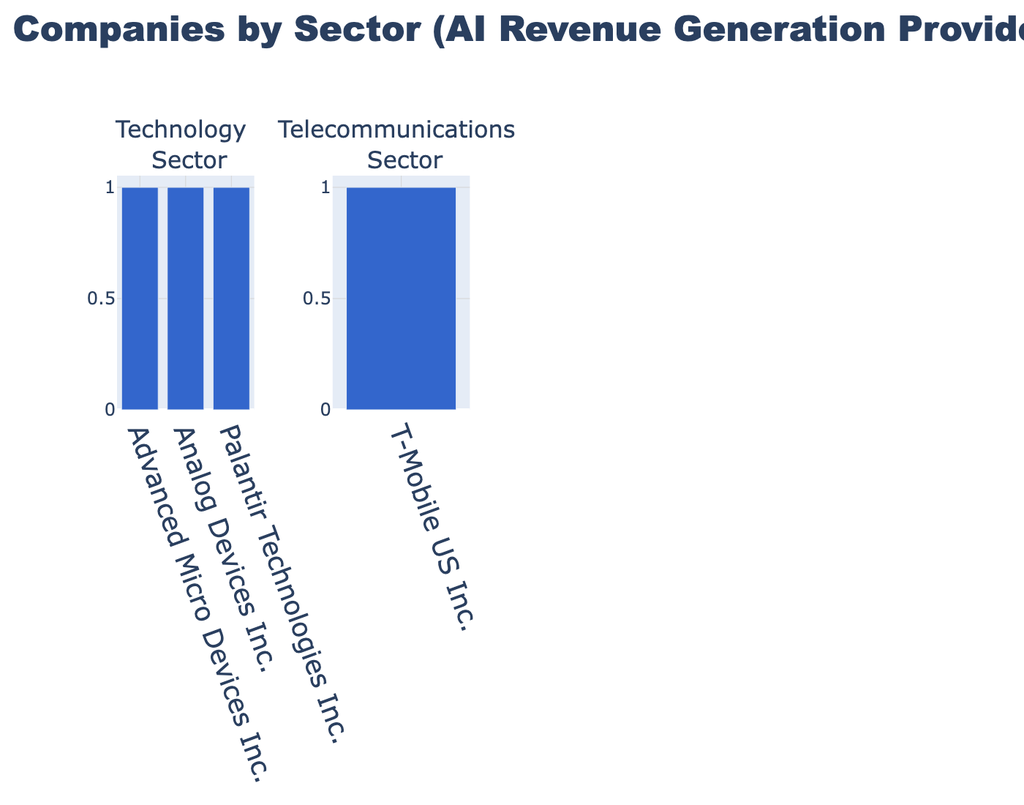

```python
if not df_providers.empty:
    plot_top_companies_by_sector(df_providers, min_companies=1, title_suffix="(AI Revenue Generation Providers)", top_sectors=4, interactive=interactive_plots)
else:
    print("No provider-labeled rows in this cost-controlled sample; skipping chart.")
```

### Companies Using AI for Revenue Generation

This complementary chart shows companies most frequently mentioned as users of AI revenue generation technology in their operations, organized by sector and ranked by total mention volume. It identifies firms investing in AI-powered sales optimization, implementing revenue enhancement systems, or boosting their profitability through AI-driven marketing and customer engagement strategies.

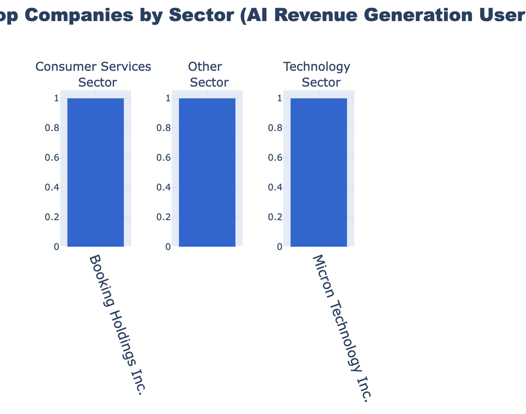

```python
if not df_users.empty:
    plot_top_companies_by_sector(df_users, min_companies=1, title_suffix="(AI Revenue Generation Users)", top_sectors=4, interactive=interactive_plots)
else:
    print("No user-labeled rows in this cost-controlled sample; skipping chart.")
```

## AI Revenue Generation Ecosystem Analysis

This comprehensive assessment combines both provider and user signals to create a complete picture of the AI revenue generation ecosystem. The analysis provides:

- **Total Exposure**: Overall volume of AI revenue generation related news coverage for each company
- **Role Classification**: Relative proportion of provider versus user mentions
- **Market Positioning**: How companies rank in terms of their involvement in the AI revenue generation market

[output not shown]

[output not shown]

[output not shown]

[output not shown]

[output not shown]

[output not shown]

[output not shown]

[output not shown]

[output not shown]

[output not shown]

[output not shown]

[output not shown]

[output not shown]

[output not shown]

[output not shown]

[output not shown]

[output not shown]

[output not shown]

[output not shown]

[output not shown]

[output not shown]

[output not shown]

[output not shown]

[output not shown]

[output not shown]

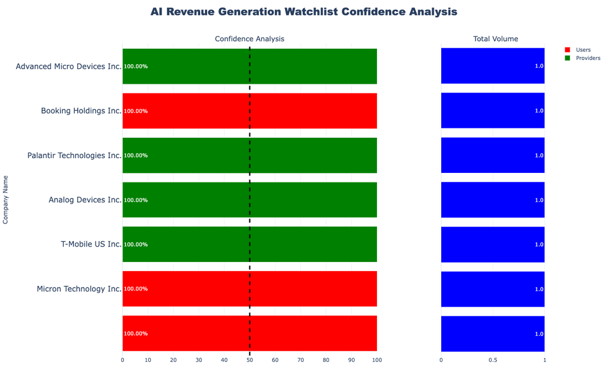

```python
if not df_providers.empty and not df_users.empty:
    companies_basket = identify_basket_and_plot_confidence(df_providers, df_users, basket_size=40, theme_name='AI Revenue Generation', positive_label='Providers', negative_label='Users', interactive=interactive_plots)
else:
    print("Insufficient provider/user rows in this cost-controlled sample; skipping basket confidence chart.")
    companies_basket = pd.DataFrame()
```

```python
companies_basket.head()
```

|  | Company | positive_exp | negative_exp | total_exposure | Sector | positive_exp_pct | negative_exp_pct | headline_positive_exp | text_positive_exp | motivation_positive_exp | headline_negative_exp | text_negative_exp | motivation_negative_exp |
| --- | --- | --- | --- | --- | --- | --- | --- | --- | --- | --- | --- | --- | --- |
| 0 |  | 0.0 | 1.0 | 1.0 | Other | 0.0 | 100.0 |  |  |  | Nvidia CEO Says Nations Seeking Own AI Systems... | Nvidia, which has become Wall Street's favorit... | has already achieved significant revenue grow... |
| 1 | Micron Technology Inc. | 0.0 | 1.0 | 1.0 | Technology | 0.0 | 100.0 |  |  |  | Micron reports Q3 EPS 62c, consensus 51c | Reports Q3 revenue $6.81B, consensus $6.67B. "... | Micron Technology Inc. directly attributes cur... |
| 2 | T-Mobile US Inc. | 1.0 | 0.0 | 1.0 | Telecommunications | 100.0 | 0.0 | Regie.ai Launches Sales Auto-Pilot; the Next G... | "The go-to-market team at Amplitude has fully ... | T-Mobile US Inc. provides an AI-powered sales ... |  |  |  |
| 3 | Analog Devices Inc. | 1.0 | 0.0 | 1.0 | Technology | 100.0 | 0.0 | Analog Devices Deploys SambaNova Suite to Faci... | SambaNova Suite is the first full stack, gener... | Analog Devices Inc. provides an enterprise gen... |  |  |  |
| 4 | Palantir Technologies Inc. | 1.0 | 0.0 | 1.0 | Technology | 100.0 | 0.0 | Palantir pitching ad agencies on utilizing AI ... | Palantir as met with advertising agencies on u... | Palantir Technologies Inc. is presenting its A... |  |  |  |

## Top Companies Time Tracking

[output not shown]

[output not shown]

[output not shown]

[output not shown]

[output not shown]

[output not shown]

[output not shown]

[output not shown]

[output not shown]

[output not shown]

[output not shown]

[output not shown]

[output not shown]

[output not shown]

[output not shown]

[output not shown]

[output not shown]

[output not shown]

[output not shown]

[output not shown]

[output not shown]

[output not shown]

[output not shown]

[output not shown]

[output not shown]

[output not shown]

[output not shown]

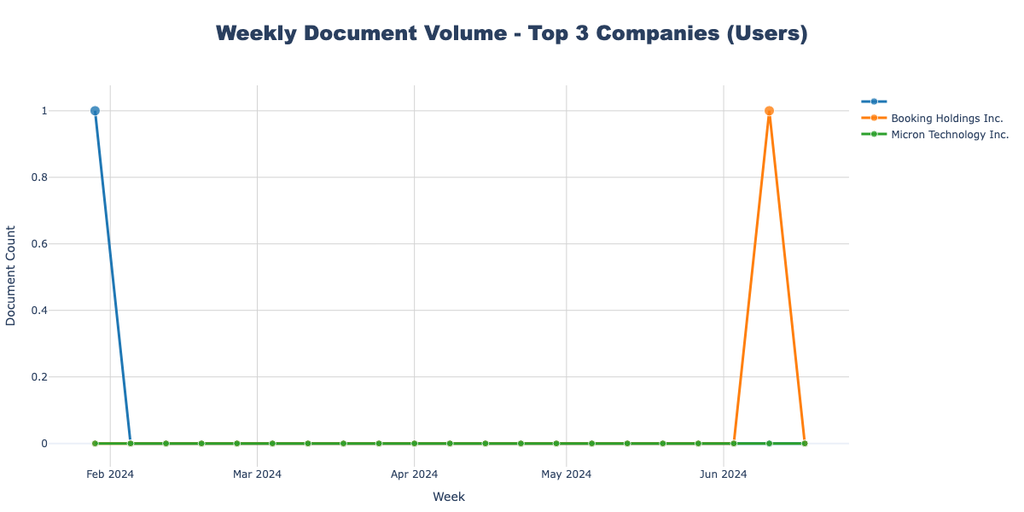

```python
if not df_users.empty:
    top_companies_time(df_users, interactive=interactive_plots)
else:
    print("No user-labeled rows in this cost-controlled sample; skipping time-tracking chart.")
```

## Provider-User Network Analysis

This network visualization reveals relationships between AI revenue generation technology providers and users through co-mentions in news articles. The analysis identifies:

- **Technology Partnerships**: Companies that frequently appear together in AI revenue generation contexts
- **Customer-Supplier Relationships**: Connections between solution providers and implementing organizations
- **Market Clusters**: Groups of companies operating in similar segments of the AI revenue generation ecosystem

Notable partnerships that may emerge include relationships between AI platform providers and enterprise users, marketing automation vendors and retail companies, and sales optimization technology developers working with early adopters to enhance their revenue generation capabilities.

```python
fig = provider_adopter_net(
    df_filtered_adopters=df_users,
    df_filtered_providers=df_providers,
    bigdata_cred=None,
    min_occurrences=3, # Change this if you want to see fewer companies in the network
    dash=False,
    interactive=interactive_plots
)
```

```
Skipping provider-adopter network chart (insufficient co-mention edges in this sample).
```

## Key Insights and Technology Stories

**Technology providers dominate the labeled basket**: Among provider-labeled rows, **Palantir Technologies Inc.**, **Analog Devices Inc.**, and **Advanced Micro Devices Inc.** sit in Technology. Palantir pitches AIP for commercial sales, pricing, inventory, and campaign optimization; Analog Devices is tied to enterprise generative AI (SambaNova) platforms; AMD links AI accelerator shipments to data-center revenue growth.

**Telecommunications provider signal**: **T-Mobile US Inc.** appears as a Telecommunications-sector provider via AI-powered sales / GTM tooling narratives (e.g. Regie.ai Auto-Pilot and CRM-connected prospecting workflows).

**Technology and Consumer Services on the user side**: **Micron Technology Inc.** (Technology) is labeled as a user with management explicitly attributing revenue growth to AI demand and AI product mix (HBM / data-center SSD). **Booking Holdings Inc.** appears under Consumer Services in the user basket for this sample.

**Sparse network in this run**: With only a handful of provider/user-labeled rows after cost control, the provider–adopter co-mention network is empty at `min_occurrences=3`. Sector charts and the ecosystem basket remain the primary readouts for this refresh.

## Export the Results

Export the data as Excel files for further analysis or to share with the team.

```python
try:
    # Plain pandas.ExcelWriter instead of the removed bigdata-research-tools ExcelManager.
    with pd.ExcelWriter(export_path, engine="openpyxl") as writer:
        df_providers.to_excel(writer, sheet_name="AI Revenue Generation Providers", index=False)
        df_users.to_excel(writer, sheet_name="AI Revenue Generation Users", index=False)
        companies_basket.to_excel(writer, sheet_name="Technology Ecosystem Basket", index=False)

    print(f"✅ Results exported to {export_path}")

except Exception as e:
    print(f"Warning while exporting to excel: {e}")
```

```
✅ Results exported to output/ai_revenue_generation_analysis_results.xlsx
```

```python
print("Runtime:", datetime.datetime.now() - start)
```

```
Runtime: 0:07:04.222563
```